# ATP Analiza mečeva

Milković Borna, Radovanović Filip, Rimac Kal, Zdenčar Noa

2026-01-17

# Dekriptivna analiza i vizualizacija podataka

Učitavanje podataka i pregled podatkovnog okvira:

```r
# učitavanje podatkovnog okvira
matches <- list.files("data/", pattern = "\\.csv$", full.names = TRUE) %>% map_df(read_csv, show_col_types = FALSE) %>% suppressWarnings()

dim(matches)
```

```
## [1] 194379     49
```

Podatci se sastoje od 194379 mečeva i 49 njihovih opisa (varijabli).

Te varijable i njihove klase (tipovi) su sljedeće:

```r
faktori <- c("tourney_name", "surface", "draw_size", "tourney_level", "winner_hand", "winner_ioc", "loser_hand", "best_of", "round")
matches[faktori] <- lapply(matches[faktori], as.factor)
sapply(matches, class)
```

```
##         tourney_id       tourney_name            surface          draw_size
##        "character"           "factor"           "factor"           "factor"
##      tourney_level       tourney_date          match_num          winner_id
##           "factor"          "numeric"          "numeric"          "numeric"
##        winner_seed       winner_entry        winner_name        winner_hand
##          "numeric"        "character"        "character"           "factor"
##          winner_ht         winner_ioc         winner_age           loser_id
##          "numeric"           "factor"          "numeric"          "numeric"
##         loser_seed        loser_entry         loser_name         loser_hand
##          "numeric"        "character"        "character"           "factor"
##           loser_ht          loser_ioc          loser_age              score
##          "numeric"        "character"          "numeric"        "character"
##            best_of              round            minutes              w_ace
##           "factor"           "factor"          "numeric"          "numeric"
##               w_df             w_svpt            w_1stIn           w_1stWon
##          "numeric"          "numeric"          "numeric"          "numeric"
##           w_2ndWon            w_SvGms          w_bpSaved          w_bpFaced
##          "numeric"          "numeric"          "numeric"          "numeric"
##              l_ace               l_df             l_svpt            l_1stIn
##          "numeric"          "numeric"          "numeric"          "numeric"
##           l_1stWon           l_2ndWon            l_SvGms          l_bpSaved
##          "numeric"          "numeric"          "numeric"          "numeric"
##          l_bpFaced        winner_rank winner_rank_points         loser_rank
##          "numeric"          "numeric"          "numeric"          "numeric"
##  loser_rank_points
##          "numeric"
```

```r
print('Prvih nekoliko redaka u varijablama koje koristimo: ')
```

```
## [1] "Prvih nekoliko redaka u varijablama koje koristimo: "
```

```r
str(matches[, c("winner_hand", "tourney_level", "surface",
                "minutes",
                "w_SvGms", "l_SvGms",
                "w_df", "l_df",
                "w_ace", "l_ace")])
```

```
## tibble [194,379 × 10] (S3: tbl_df/tbl/data.frame)
##  $ winner_hand  : Factor w/ 4 levels "A","L","R","U": 4 3 4 3 3 4 3 3 3 4 ...
##  $ tourney_level: Factor w/ 6 levels "A","D","F","G",..: 1 1 1 1 1 1 1 1 1 1 ...
##  $ surface      : Factor w/ 4 levels "Carpet","Clay",..: 3 3 3 3 3 3 3 3 3 3 ...
##  $ minutes      : num [1:194379] NA NA NA NA NA NA NA NA NA NA ...
##  $ w_SvGms      : num [1:194379] NA NA NA NA NA NA NA NA NA NA ...
##  $ l_SvGms      : num [1:194379] NA NA NA NA NA NA NA NA NA NA ...
##  $ w_df         : num [1:194379] NA NA NA NA NA NA NA NA NA NA ...
##  $ l_df         : num [1:194379] NA NA NA NA NA NA NA NA NA NA ...
##  $ w_ace        : num [1:194379] NA NA NA NA NA NA NA NA NA NA ...
##  $ l_ace        : num [1:194379] NA NA NA NA NA NA NA NA NA NA ...
```

Vidimo da puno podataka nedostaje (barem u prvih nekoliko redaka). Provjerimo koliko je ukupno nedostajućih vrijednosti za pojedinu varijablu.

```r
for (col_name in names(matches)){
  if (sum(is.na(matches[,col_name])) > 0){
    cat('Ukupno nedostajućih vrijednosti za varijablu ',col_name, ': ', sum(is.na(matches[,col_name])),'\n')
  }
}
```

```
## Ukupno nedostajućih vrijednosti za varijablu  surface :  2937
## Ukupno nedostajućih vrijednosti za varijablu  draw_size :  835
## Ukupno nedostajućih vrijednosti za varijablu  winner_seed :  122399
## Ukupno nedostajućih vrijednosti za varijablu  winner_entry :  177245
## Ukupno nedostajućih vrijednosti za varijablu  winner_hand :  12
## Ukupno nedostajućih vrijednosti za varijablu  winner_ht :  16855
## Ukupno nedostajućih vrijednosti za varijablu  winner_ioc :  8
## Ukupno nedostajućih vrijednosti za varijablu  winner_age :  1310
## Ukupno nedostajućih vrijednosti za varijablu  loser_seed :  157674
## Ukupno nedostajućih vrijednosti za varijablu  loser_entry :  165357
## Ukupno nedostajućih vrijednosti za varijablu  loser_hand :  49
## Ukupno nedostajućih vrijednosti za varijablu  loser_ht :  29609
## Ukupno nedostajućih vrijednosti za varijablu  loser_ioc :  72
## Ukupno nedostajućih vrijednosti za varijablu  loser_age :  4652
## Ukupno nedostajućih vrijednosti za varijablu  score :  9
## Ukupno nedostajućih vrijednosti za varijablu  minutes :  99893
## Ukupno nedostajućih vrijednosti za varijablu  w_ace :  96887
## Ukupno nedostajućih vrijednosti za varijablu  w_df :  96888
## Ukupno nedostajućih vrijednosti za varijablu  w_svpt :  96888
## Ukupno nedostajućih vrijednosti za varijablu  w_1stIn :  96888
## Ukupno nedostajućih vrijednosti za varijablu  w_1stWon :  96888
## Ukupno nedostajućih vrijednosti za varijablu  w_2ndWon :  96888
## Ukupno nedostajućih vrijednosti za varijablu  w_SvGms :  96888
## Ukupno nedostajućih vrijednosti za varijablu  w_bpSaved :  96888
## Ukupno nedostajućih vrijednosti za varijablu  w_bpFaced :  96888
## Ukupno nedostajućih vrijednosti za varijablu  l_ace :  96888
## Ukupno nedostajućih vrijednosti za varijablu  l_df :  96887
## Ukupno nedostajućih vrijednosti za varijablu  l_svpt :  96888
## Ukupno nedostajućih vrijednosti za varijablu  l_1stIn :  96888
## Ukupno nedostajućih vrijednosti za varijablu  l_1stWon :  96888
## Ukupno nedostajućih vrijednosti za varijablu  l_2ndWon :  96888
## Ukupno nedostajućih vrijednosti za varijablu  l_SvGms :  96888
## Ukupno nedostajućih vrijednosti za varijablu  l_bpSaved :  96888
## Ukupno nedostajućih vrijednosti za varijablu  l_bpFaced :  96888
## Ukupno nedostajućih vrijednosti za varijablu  winner_rank :  35766
## Ukupno nedostajućih vrijednosti za varijablu  winner_rank_points :  82989
## Ukupno nedostajućih vrijednosti za varijablu  loser_rank :  44162
## Ukupno nedostajućih vrijednosti za varijablu  loser_rank_points :  84642
```

Iz priloženog možemo vidjeti da najviše podataka nedostaje za varijable winner_entry, loser_seed i loser_entry (više od 80%), no te varijable nećemo niti koristiti u analizi mečeva tako da ih nećemo uklanjati. Velik broj podataka nedostaje i kod ostalih varijabli poput statistike servisa i poena, trajanja meča, rankinga, bodova… Većina tih podataka nedostaje na početku skupa podataka u kojem se nalaze podaci još od 1968. godine (početak Open ere) kada se ti podaci nisu bilježili ni mjerili, dok su npr. ATP rankinzi uvedeni tek 1973. godine.

Promotrimo sada kako izgledaju neke od varijabli nad kojima ćemo kasnije provesti analizu.

```r
summary(
  transform(
    matches[
      ,
      c("winner_hand", "tourney_level", "surface",
        "minutes",
        "w_SvGms", "l_SvGms",
        "w_df", "l_df",
        "w_ace", "l_ace")
    ],
    total_aces  = w_ace + l_ace,
    total_df    = w_df + l_df,
    total_SvGms = w_SvGms + l_SvGms
  )[ ,
    c("winner_hand", "tourney_level", "surface",
      "minutes",
      "total_aces", "total_df", "total_SvGms")
  ]
)
```

```
##  winner_hand   tourney_level   surface         minutes         total_aces
##  A   :   100   A:127380      Carpet:20900   Min.   :   0.0   Min.   :  0.00
##  L   : 27965   D: 14666      Clay  :69395   1st Qu.:  75.0   1st Qu.:  6.00
##  R   :164288   F:   579      Grass :23397   Median :  97.0   Median : 10.00
##  U   :  2014   G: 27537      Hard  :77750   Mean   : 104.2   Mean   : 11.41
##  NA's:    12   M: 24153      NA's  : 2937   3rd Qu.: 126.0   3rd Qu.: 15.00
##                O:    64                     Max.   :1146.0   Max.   :216.00
##                                             NA's   :99893    NA's   :96888
##     total_df       total_SvGms
##  Min.   : 0.000   Min.   :  0.00
##  1st Qu.: 3.000   1st Qu.: 19.00
##  Median : 5.000   Median : 22.00
##  Mean   : 6.194   Mean   : 24.63
##  3rd Qu.: 8.000   3rd Qu.: 29.00
##  Max.   :42.000   Max.   :181.00
##  NA's   :96888    NA's   :96888
```

Promotrimo najprije numeričke varijable.

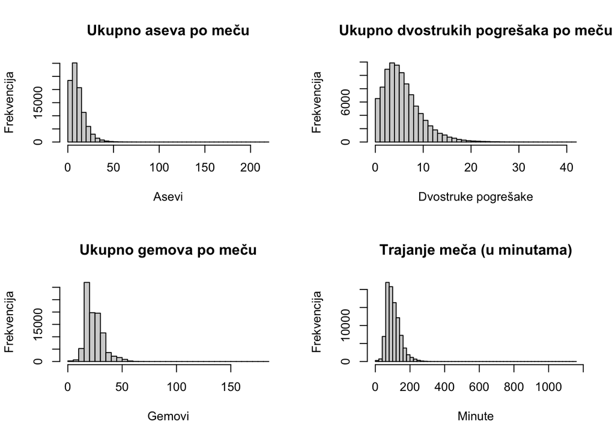

```r
par(mfrow = c(2, 2))
h1 <- hist(matches$w_ace + matches$l_ace, main = "Ukupno aseva po meču", xlab = "Asevi", ylab = "Frekvencija", breaks = 50)

h2 <- hist(matches$w_df + matches$l_df, main = "Ukupno dvostrukih pogrešaka po meču", xlab = "Dvostruke pogrešake", ylab = "Frekvencija", breaks = 50)

h3 <- hist(matches$w_SvGms + matches$l_SvGms, main = "Ukupno gemova po meču", xlab = "Gemovi", ylab = "Frekvencija", breaks = 50)

h4 <- hist(matches$minutes, main = "Trajanje meča (u minutama)", xlab = "Minute", ylab = "Frekvencija", breaks = 50)
```

Pokušajmo log transformacijom i izbacivanjem ekstremnih vrijednosti približiti podatke normalnoj distribuciji.

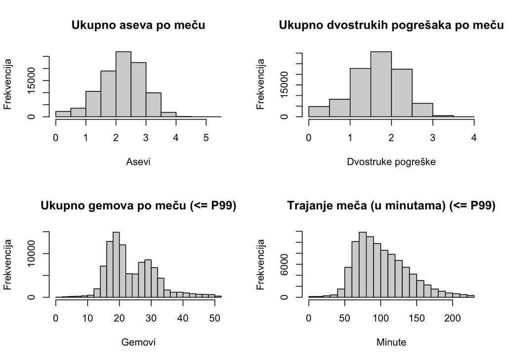

```r
par(mfrow = c(2, 2))
h_log1 <- hist(log(matches$w_ace + matches$l_ace), main = "Ukupno aseva po meču", xlab = "Asevi", ylab = "Frekvencija", breaks = 10)

h_log2 <- hist(log(matches$w_df + matches$l_df), main = "Ukupno dvostrukih pogrešaka po meču", xlab = "Dvostruke pogreške", ylab = "Frekvencija", breaks = 10)

total_gems <- matches$w_SvGms + matches$l_SvGms
cutoff <- quantile(total_gems, 0.99, na.rm = TRUE)
h_log3 <- hist(total_gems[total_gems <= cutoff], main = "Ukupno gemova po meču (<= P99)", xlab = "Gemovi", ylab = "Frekvencija", breaks = 30)

cutoff <- quantile(matches$minutes, 0.99, na.rm = TRUE)
h_log4 <- hist(matches$minutes[matches$minutes <= cutoff], main = "Trajanje meča (u minutama) (<= P99)", xlab = "Minute", ylab = "Frekvencija", breaks = 30)
```

Podaci ne izgledaju daleko od normalne distribucije, no postoje odstupanja zbog nekih ekstremnih vrijednosti i zbog toga što se u skupu podataka nalaze podaci o mečevima koji su igrani i do 2 i do 3 osvojena seta.

Promotrimo sada kategoričke varijable.

```r
print('Pobjednikova preferirana ruka: ')
table(matches$winner_hand)
```

```
## [1] "Pobjednikova preferirana ruka: "
##
##      A      L      R      U
##    100  27965 164288   2014
```

Primijetimo da varijabla “winner_hand” sadrži i igrače s nedefiniranom (U) preferiranom rukom te igrače koji udaraju lopticu s obje ruke - samo forehandom (A) pa trebamo paziti na te varijable u daljnjoj analizi.

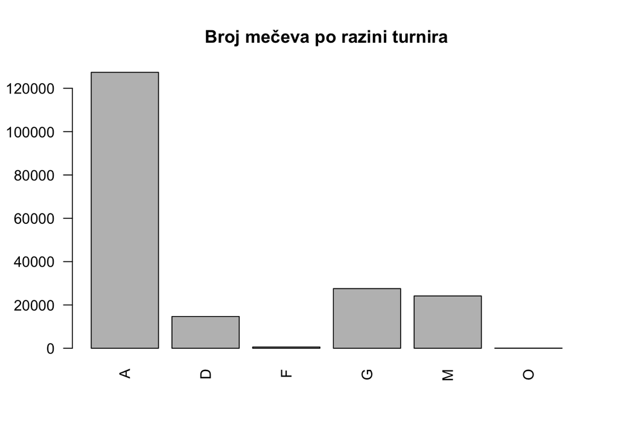

```r
barplot(table(matches$tourney_level),las=2,main='Broj mečeva po razini turnira')
```

```r
print('Broj mečeva po razini turnira: ')
table(matches$tourney_level)
```

```
## [1] "Broj mečeva po razini turnira: "
##
##      A      D      F      G      M      O
## 127380  14666    579  27537  24153     64
```

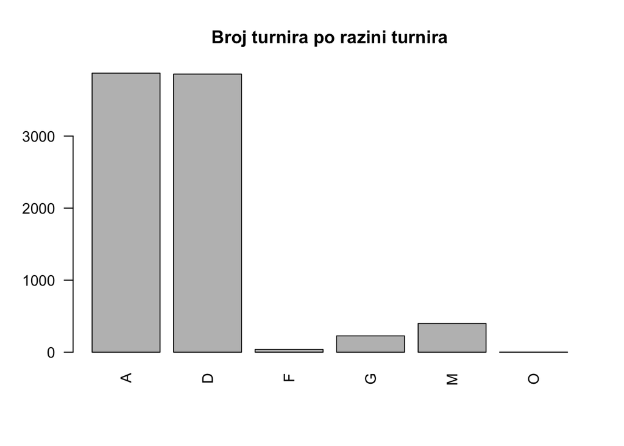

```r
barplot(table(unique(matches[, c("tourney_id", "tourney_level")])$tourney_level), las=2, main='Broj turnira po razini turnira')
```

```r
print('Broj turnira po razini turnira: ')
table(unique(matches[, c("tourney_id", "tourney_level")])$tourney_level)
```

```
## [1] "Broj turnira po razini turnira: "
##
##    A    D    F    G    M    O
## 3873 3860   39  227  399    1
```

Turniri su podijeljeni na 6 kategorija ovisno o jačini i vrsti turnira: ATP 250 (i 500), Davis Cup, ATP Finals, Grand Slam, Masters 1000 i Olympics. ATP 250/500 mečeva ima daleko najviše jer ima jako puno tih turnira kroz godinu i postoje već dugo godina dok je mečeva na Olimpijskih igrama i ATP Finalsu vrlo malo zbog toga što su to rijetki događaji s manjim brojem sudionika.

```r
table(matches$tourney_level, matches$best_of)
```

```
##
##          1      3      5
##   A     36 123228   4116
##   D      0   4366  10300
##   F      0    540     39
##   G      0    271  27266
##   M      0  23323    830
##   O      0     64      0
```

Isto tako, ovdje vidimo vrste turnira i broj setova koji se igra na pojedinom turniru (best_of varijabla). Osim već spomenutih best of 3 i best of 5, vidimo da postoje i neki mečevi koji su se igrali na best of 1 (vjerojatno davno igrani ili neki egzibicijski mečevi) koje trebamo ukloniti prilikom analize kasnije. Gotovo svaka vrsta turnira ima podatke i za best of 3 i za best of 5 zbog toga što su se kroz povijest formati turnira znali mijenjati.

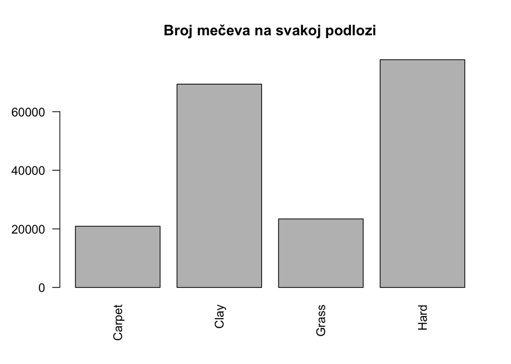

```r
barplot(table(matches$surface),las=2,main='Broj mečeva na svakoj podlozi')
```

```r
print('Broj mečeva na svakoj podlozi: ')
table(matches$surface)
```

```
## [1] "Broj mečeva na svakoj podlozi: "
##
## Carpet   Clay  Grass   Hard
##  20900  69395  23397  77750
```

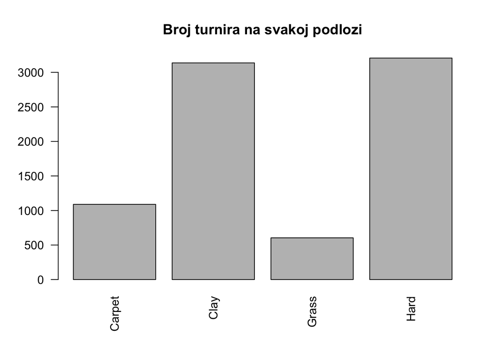

```r
barplot(table(unique(matches[, c("tourney_id", "surface")])$surface),las=2,main='Broj turnira na svakoj podlozi')
```

```r
print('Broj turnira na svakoj podlozi: ')
table(unique(matches[, c("tourney_id", "surface")])$surface)
```

```
## [1] "Broj turnira na svakoj podlozi: "
##
## Carpet   Clay  Grass   Hard
##   1089   3137    604   3207
```

Možemo vidjeti da je najviše mečeva i turnira odigrano na zemlji i tvrdoj podlozi, dok je na travi i tepihu puno manje. Razlog tomu je što se na tvrdoj podlozi može igrati kroz cijelu sezonu (indoor i outdoor), a iako se na zemlji igra samo mali dio sezone (otprilike od travnja do lipnja), taj dio sezone je najintenzivniji i osim velikog broja mečeva po turniru ima i jako puno turnira koji se u to vrijeme igraju uglavnom na zemlji.

# Je li distribucija pobjeda po ruci kojom se igra povezana s vrstom turnira?

S obzirom na to da pitanje ukazuje na ispitivanje zavisnosti dvije varijable, kako bismo našli odgovor koristit ćemo Chi2 test nezavisnosti. Nužan uvjet za korištenje ovog testa je da su sve očekivane vrijednosti izračunate iz kontingencijske tablice veće od 5.

Za početak gledamo moguće vrijednosti obje varijable i njihovu zastupljenost u uzorku.

```r
levels(matches$winner_hand)
```

```
## [1] "A" "L" "R" "U"
```

```r
levels(matches$tourney_level)
```

```
## [1] "A" "D" "F" "G" "M" "O"
```

```r
table(matches$winner_hand)
```

```
##
##      A      L      R      U
##    100  27965 164288   2014
```

```r
table(matches$tourney_level)
```

```
##
##      A      D      F      G      M      O
## 127380  14666    579  27537  24153     64
```

Gledamo koliko ima nedostajućih ili nepoznatih(“U”) vrijednosti za pobjedu po ruci i izbacujemo te podatke s obzirom da čine mali udio podataka ((12 + 2014)/194379).

```r
matches$winner_hand %>% is.na() %>% sum()
```

```
## [1] 12
```

```r
table(matches$winner_hand)["U"]
```

```
##    U
## 2014
```

```r
matches1 <- matches[is.na(matches$winner_hand) == F, ]
matches1 <- matches1[matches1$winner_hand != 'U', ]

table(matches1$winner_hand)
```

```
##
##      A      L      R      U
##    100  27965 164288      0
```

```r
matches1$winner_hand <- as.factor(matches1$winner_hand)
```

Gradimo kontingencijsku tablicu i računamo očekivane vrijednosti kako bismo provjerili da su sve veće od 5.

```r
tablica_ruka = table(matches1$winner_hand)
tablica_vrsta_turnira = table(matches1$tourney_level)

tbl = table(matches1$winner_hand, matches1$tourney_level)[-4, ]
tbl
```

```
##
##          A      D      F      G      M      O
##   A     73     20      0      6      1      0
##   L  19101   1466     39   4020   3332      7
##   R 107290  12143    540  23480  20778     57
```

```r
added_margins_tbl = addmargins(tbl)
print(added_margins_tbl)
```

```
##
##            A      D      F      G      M      O    Sum
##   A       73     20      0      6      1      0    100
##   L    19101   1466     39   4020   3332      7  27965
##   R   107290  12143    540  23480  20778     57 164288
##   Sum 126464  13629    579  27506  24111     64 192353
```

```r
for (col_names in colnames(added_margins_tbl)){
  for (row_names in rownames(added_margins_tbl)){
    if (!(row_names == 'Sum' | col_names == 'Sum') ){
      cat('Očekivane frekvencije za razred ',col_names,'-',row_names,': ',(added_margins_tbl[row_names,'Sum'] * added_margins_tbl['Sum',col_names]) / added_margins_tbl['Sum','Sum'],'\n')
    }
  }
}
```

```
## Očekivane frekvencije za razred  A - A :  65.74579
## Očekivane frekvencije za razred  A - L :  18385.81
## Očekivane frekvencije za razred  A - R :  108012.4
## Očekivane frekvencije za razred  D - A :  7.085411
## Očekivane frekvencije za razred  D - L :  1981.435
## Očekivane frekvencije za razred  D - R :  11640.48
## Očekivane frekvencije za razred  F - A :  0.3010091
## Očekivane frekvencije za razred  F - L :  84.17719
## Očekivane frekvencije za razred  F - R :  494.5218
## Očekivane frekvencije za razred  G - A :  14.29975
## Očekivane frekvencije za razred  G - L :  3998.925
## Očekivane frekvencije za razred  G - R :  23492.77
## Očekivane frekvencije za razred  M - A :  12.53477
## Očekivane frekvencije za razred  M - L :  3505.348
## Očekivane frekvencije za razred  M - R :  20593.12
## Očekivane frekvencije za razred  O - A :  0.03327216
## Očekivane frekvencije za razred  O - L :  9.30456
## Očekivane frekvencije za razred  O - R :  54.66217
```

Nalazimo dvije vrijednosti manje od 5, opažamo da obje pripadaju retku A(ambidextrous), a s obzirom da ti podaci čine tek nekolicinu cijelog uzorka(njih 100 od 192353) odlučujemo ih izbaciti. Ponovno gradimo kontingencijsku tablicu i računamo očekivane vrijednosti.

```r
matches1 <- matches1[matches1$winner_hand != 'A', ]
tbl = table(matches1$winner_hand, matches1$tourney_level)[-c(1, 4), ]
tbl
```

```
##
##          A      D      F      G      M      O
##   L  19101   1466     39   4020   3332      7
##   R 107290  12143    540  23480  20778     57
```

```r
added_margins_tbl = addmargins(tbl)
print(added_margins_tbl)
```

```
##
##            A      D      F      G      M      O    Sum
##   L    19101   1466     39   4020   3332      7  27965
##   R   107290  12143    540  23480  20778     57 164288
##   Sum 126391  13609    579  27500  24110     64 192253
```

```r
for (col_names in colnames(added_margins_tbl)){
  for (row_names in rownames(added_margins_tbl)){
    if (!(row_names == 'Sum' | col_names == 'Sum') ){
      cat('Očekivane frekvencije za razred ',col_names,'-',row_names,': ',(added_margins_tbl[row_names,'Sum'] * added_margins_tbl['Sum',col_names]) / added_margins_tbl['Sum','Sum'],'\n')
    }
  }
}
```

```
## Očekivane frekvencije za razred  A - L :  18384.76
## Očekivane frekvencije za razred  A - R :  108006.2
## Očekivane frekvencije za razred  D - L :  1979.557
## Očekivane frekvencije za razred  D - R :  11629.44
## Očekivane frekvencije za razred  F - L :  84.22097
## Očekivane frekvencije za razred  F - R :  494.779
## Očekivane frekvencije za razred  G - L :  4000.133
## Očekivane frekvencije za razred  G - R :  23499.87
## Očekivane frekvencije za razred  M - L :  3507.025
## Očekivane frekvencije za razred  M - R :  20602.97
## Očekivane frekvencije za razred  O - L :  9.3094
## Očekivane frekvencije za razred  O - R :  54.6906
```

Sada su sve očekivane frekvencije veće od 5, nastavljamo s Chi2 testom. Hipoteze: H0: Distribucija pobjeda po ruci nije povezana s vrstom turnira(varijable su nezavisne). H1: Distribucija pobjeda po ruci je povezana s vrstom turnira(varijable nisu nezavisne).

Test provodimo na razini značajnosti alfa = 0.05.

```r
chisq.test(tbl,correct=F)
```

```
##
##  Pearson's Chi-squared test
##
## data:  tbl
## X-squared = 227.99, df = 5, p-value < 2.2e-16
```

S obzirom da je p-vrijednost << 0.05, odbacujemo H0 u korist H1 i zaključujemo da je distribucija pobjeda po ruci povezana s vrstom turnira.

# Imaju li mečevi odigrani na travi prosječno manje gemova od mečeva na zemlji?

U ovom pitanju traži se usporedba srednjih vrijednosti dvije populacije, za što je prikladno koristiti t-test. T-test ima dvije varijante, ovisno o tome jesu li varijance populacija jednake ili različite. Osim toga, zahtjeva da uzorci dolaze iz nezavisnih normalno distribuiranih populacija.

Kako u podacima nema atributa koji navodi ukupan broj gemova po meču, računamo ga iz stupaca w_SvGms i l_SvGms. Osim toga, čistimo podatke od nedokumentiranih vrijednosti i dijelimo ih po vrsti podloge.

```r
table(matches$surface)
```

```
##
## Carpet   Clay  Grass   Hard
##  20900  69395  23397  77750
```

```r
# izbaci NA vrijednosti
matches2 <- matches[is.na(matches$surface) == F & is.na(matches$w_SvGms) == F & is.na(matches$l_SvGms) == F,]

#dodaj stupac s ukupnim brojem gemova
matches2 <- mutate(matches2, games = matches2$w_SvGms + matches2$l_SvGms)


clay_matches = matches2[matches2$surface == "Clay", ]
grass_matches = matches2[matches2$surface == "Grass", ]


cat('Prosječan broj gemova odigranih na zemlji', mean(clay_matches$games),'\n')
```

```
## Prosječan broj gemova odigranih na zemlji 23.70754
```

```r
cat('Prosječan broj gemova odigranih na travi', mean(grass_matches$games),'\n')
```

```
## Prosječan broj gemova odigranih na travi 28.33432
```

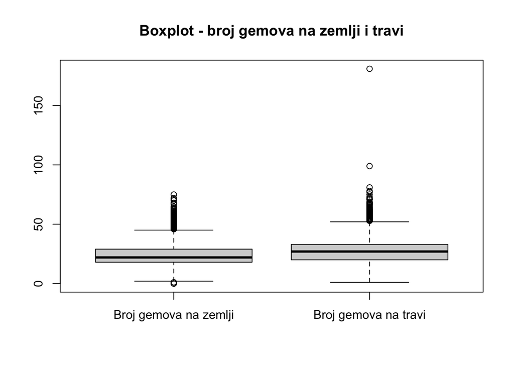

```r
boxplot(clay_matches$games, grass_matches$games,
        names = c('Broj gemova na zemlji','Broj gemova na travi'),
        main='Boxplot - broj gemova na zemlji i travi')
```

Na grafu se ističu izrazito stršeće vrijednosti, stoga ćemo ukloniti sve vrijednosti veće od 65, što je ujedno i maksimalni broj gemova u današnjem tenisu.

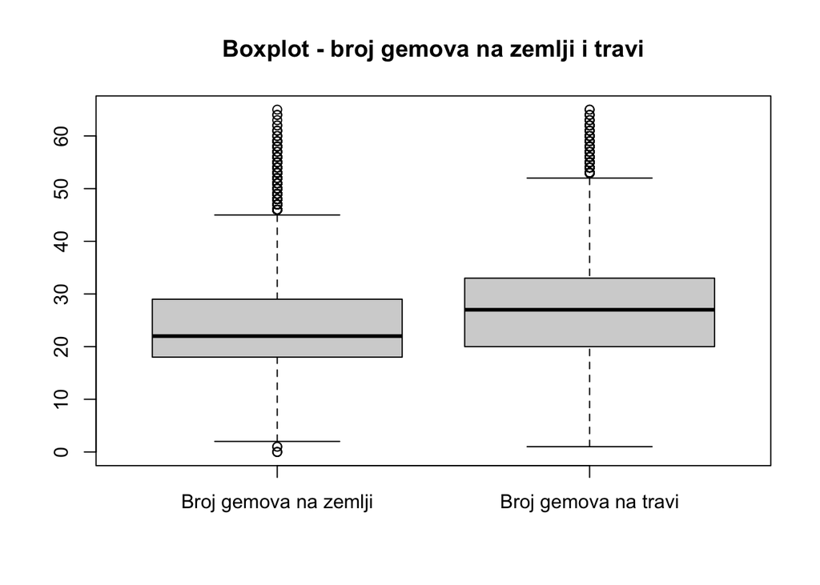

```r
ind <- which(matches2$games > 65)
matches2 <- matches2[-ind,]

clay_matches = matches2[matches2$surface == "Clay", ]
grass_matches = matches2[matches2$surface == "Grass", ]

boxplot(clay_matches$games, grass_matches$games,
        names = c('Broj gemova na zemlji','Broj gemova na travi'),
        main='Boxplot - broj gemova na zemlji i travi')
```

Grafovi upućuju na to da bi prosječan broj gemova odigran na travnatim podlogama mogao biti veći od prosječnog broja gemova odigranih na zemljanim podlogama.

Provjera normalnosti uzorka:

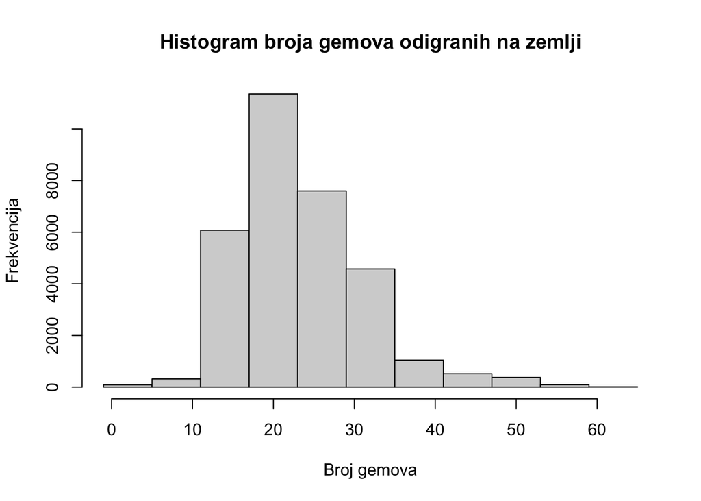

```r
hist(clay_matches$games,
     breaks=seq(min(clay_matches$games) -1,max(clay_matches$games) + 2,6),
     main='Histogram broja gemova odigranih na zemlji',
     xlab='Broj gemova', ylab='Frekvencija')
```